# Fraud_detection

- Data processing and cleaning
- Exploratory data analysis (EDA)
- Detection models

# 1. Data processing and cleaning

## 1.1. Import datdata

```r
library(tidyverse)
fraud_df <- read_csv("C:/Users/admin/OneDrive - THPT Lê Hồng Phong/Git/Fraud_detection/banking_transactions.csv")
head(fraud_df)
```

| transaction_id | transaction_amount | login_attempts | device_risk_score | transfer_frequency | anomaly_score | account_age_days | transaction_time_hour | failed_transactions_last_30d | avg_monthly_balance | daily_transaction_count | geo_distance_km | session_duration_minutes | transaction_velocity_score | payment_channel | authentication_type | card_present_flag | international_transaction_flag | suspicious_ip_flag | fraud_flag |
| --- | --- | --- | --- | --- | --- | --- | --- | --- | --- | --- | --- | --- | --- | --- | --- | --- | --- | --- | --- |
| 1000001 | 17829.01 | 4 | 12.0 | 13 | 0.37 | 2354 | 22 | 25 | 112760.07 | 63 | 3189 | 92 | 71.8 | POS Terminal | OTP | 1 | 1 | 1 | FALSE |
| 1000002 | 16401.83 | 1 | 34.3 | 17 | 0.26 | 3181 | 17 | 15 | 118899.52 | 83 | 839 | 63 | 11.8 | Web Banking | Biometric | 0 | 0 | 1 | FALSE |
| 1000003 | 9678.29 | 8 | 67.8 | 39 | 0.15 | 1390 | 3 | 2 | 408168.98 | 9 | 3938 | 80 | 35.7 | ATM | OTP | 1 | 0 | 1 | FALSE |
| 1000004 | 19013.38 | 5 | 17.8 | 42 | 0.55 | 3716 | 16 | 6 | 80771.69 | 78 | 11111 | 11 | 74.8 | Mobile App | OTP | 1 | 1 | 0 | FALSE |
| 1000005 | 13834.95 | 3 | 88.9 | 63 | 0.24 | 4694 | 16 | 10 | 382265.32 | 17 | 3171 | 87 | 0.0 | Mobile App | OTP | 1 | 0 | 0 | FALSE |
| 1000006 | 17501.15 | 9 | 81.5 | 55 | 0.24 | 3842 | 12 | 0 | 204382.64 | 85 | 10126 | 99 | 43.0 | Mobile App | Two-Factor Authentication | 0 | 0 | 1 | FALSE |

Overview về bộ dữ liệu

```r
str(fraud_df)
```

```
spc_tbl_ [10,000 × 20] (S3: spec_tbl_df/tbl_df/tbl/data.frame)
 $ transaction_id                : num [1:10000] 1e+06 1e+06 1e+06 1e+06 1e+06 ...
 $ transaction_amount            : num [1:10000] 17829 16402 9678 19013 13835 ...
 $ login_attempts                : num [1:10000] 4 1 8 5 3 9 5 7 7 1 ...
 $ device_risk_score             : num [1:10000] 12 34.3 67.8 17.8 88.9 81.5 17.2 46.6 15.9 84.5 ...
 $ transfer_frequency            : num [1:10000] 13 17 39 42 63 55 75 34 37 61 ...
 $ anomaly_score                 : num [1:10000] 0.37 0.26 0.15 0.55 0.24 0.24 0.56 0.42 0.2 0.38 ...
 $ account_age_days              : num [1:10000] 2354 3181 1390 3716 4694 ...
 $ transaction_time_hour         : num [1:10000] 22 17 3 16 16 12 8 4 11 14 ...
 $ failed_transactions_last_30d  : num [1:10000] 25 15 2 6 10 0 18 13 13 17 ...
 $ avg_monthly_balance           : num [1:10000] 112760 118900 408169 80772 382265 ...
 $ daily_transaction_count       : num [1:10000] 63 83 9 78 17 85 12 63 104 17 ...
 $ geo_distance_km               : num [1:10000] 3189 839 3938 11111 3171 ...
 $ session_duration_minutes      : num [1:10000] 92 63 80 11 87 99 97 20 20 34 ...
 $ transaction_velocity_score    : num [1:10000] 71.8 11.8 35.7 74.8 0 43 50.6 97.7 73 47.2 ...
 $ payment_channel               : chr [1:10000] "POS Terminal" "Web Banking" "ATM" "Mobile App" ...
 $ authentication_type           : chr [1:10000] "OTP" "Biometric" "OTP" "OTP" ...
 $ card_present_flag             : num [1:10000] 1 0 1 1 1 0 1 1 1 0 ...
 $ international_transaction_flag: num [1:10000] 1 0 0 1 0 0 0 1 1 1 ...
 $ suspicious_ip_flag            : num [1:10000] 1 1 1 0 0 1 0 0 0 1 ...
 $ fraud_flag                    : logi [1:10000] FALSE FALSE FALSE FALSE FALSE FALSE ...
 - attr(*, "spec")=
  .. cols(
  ..   transaction_id = col_double(),
  ..   transaction_amount = col_double(),
  ..   login_attempts = col_double(),
  ..   device_risk_score = col_double(),
  ..   transfer_frequency = col_double(),
  ..   anomaly_score = col_double(),
  ..   account_age_days = col_double(),
  ..   transaction_time_hour = col_double(),
  ..   failed_transactions_last_30d = col_double(),
  ..   avg_monthly_balance = col_double(),
  ..   daily_transaction_count = col_double(),
  ..   geo_distance_km = col_double(),
  ..   session_duration_minutes = col_double(),
  ..   transaction_velocity_score = col_double(),
  ..   payment_channel = col_character(),
  ..   authentication_type = col_character(),
  ..   card_present_flag = col_double(),
  ..   international_transaction_flag = col_double(),
  ..   suspicious_ip_flag = col_double(),
  ..   fraud_flag = col_logical()
  .. )
 - attr(*, "problems")=<externalptr>
```

## 1.2. Cleaning data

### 1.2.1. Missing value

```r
sapply(fraud_df, function(x) sum(is.na(x)))
```

```
                transaction_id             transaction_amount
                             0                              0
                login_attempts              device_risk_score
                             0                              0
            transfer_frequency                  anomaly_score
                             0                              0
              account_age_days          transaction_time_hour
                             0                              0
  failed_transactions_last_30d            avg_monthly_balance
                             0                              0
       daily_transaction_count                geo_distance_km
                             0                              0
      session_duration_minutes     transaction_velocity_score
                             0                              0
               payment_channel            authentication_type
                             0                              0
             card_present_flag international_transaction_flag
                             0                              0
            suspicious_ip_flag                     fraud_flag
                             0                              0
```

### 1.2.2. Duplicate data

```r
sum(duplicated(fraud_df))
```

```
[1] 0
```

### 1.2.3. Biến đổi dữ liệu sử dụng để phân tích

```r
EDA_df <- fraud_df %>%
  mutate(

    # Risk tier
    risk_tier = cut(
      anomaly_score,
      breaks = c(0, 0.3, 0.6, 0.8, 1),
      labels = c("Low", "Medium", "High", "Critical"),
      include.lowest = TRUE
    ),

    # Time of day
    time_of_day = case_when(
      transaction_time_hour >= 0  & transaction_time_hour < 6  ~ "Night",
      transaction_time_hour >= 6  & transaction_time_hour < 12 ~ "Morning",
      transaction_time_hour >= 12 & transaction_time_hour < 18 ~ "Afternoon",
      TRUE ~ "Evening"
    ),

    # Composite high-risk flag
    high_risk_combo = if_else(
      suspicious_ip_flag == 1 &
      international_transaction_flag == 1 &
      anomaly_score > 0.7,
      1L,
      0L
    ),

    # Account maturity
    account_maturity = cut(
      account_age_days,
      breaks = c(0, 365, 730, 1825, 3650, Inf),
      labels = c("<1 yr", "1-2 yr", "2-5 yr", "5-10 yr", ">10 yr"),
      include.lowest = TRUE
    ),

    # Amount tier
    amount_tier = cut(
      transaction_amount,
      breaks = c(0, 5000, 10000, 15000, 20000, Inf),
      labels = c("<5K", "5-10K", "10-15K", "15-20K", ">20K"),
      include.lowest = TRUE
    )

  )
```

# 2. EDA

## 2.1. Data aggregation

**Tính số lượng và % giao dịch fraud trên các kênh giao dịch (payment channel)**

```r
EDA_df%>%
  group_by(payment_channel) %>%
  summarise(
    fraud_rate = round(mean(fraud_flag)*100,2),
    count = n()
  )
```

[output not shown]

**Tính số lượng và % giao dịch fraud trên các kiểu xác thực (authentication type)**

```r
EDA_df%>%
  group_by(authentication_type) %>%
  summarise(
    fraud_rate = round(mean(fraud_flag)*100,2),
    count = n()
  )
```

[output not shown]

**Các thời điểm hay xảy ra các giao dịch gian lận:**

```r
EDA_df%>%
  group_by(transaction_time_hour) %>%
  summarise(
    fraud_rate = round(mean(fraud_flag),4),
    volume = n()
  )%>%
  arrange(desc(fraud_rate))%>%
  slice_head(n = 5)
```

[output not shown]

```r
EDA_df%>%
  group_by(account_maturity) %>%
  summarise(
    fraud_rate = round(mean(fraud_flag),4),
    count = n())
```

[output not shown]

## 2.2. Visualization

### 2.2.1. Phân phối của anomaly_score

```r
ggplot(
  fraud_df,
  aes(
    x = anomaly_score,
    fill = fraud_flag,
    color = fraud_flag
  )
) +

  geom_density(
    alpha = 0.3
  ) +

  geom_vline(
    xintercept = 0.7,
    color = "red",
    linetype = "dashed",
    linewidth = 1
  ) +


  labs(
    title = "Distribution of Anomaly Scores",
    subtitle = "Fraudulent transactions tend to exhibit higher anomaly scores",
    x = "Anomaly Score",
    y = "Density"
  ) +

  theme_minimal(base_size = 13)
```

[output not shown]

### 2.2.2. Risk heatmap theo giờ giao dịch

```r
hourly_data <- EDA_df %>%
  group_by(transaction_time_hour) %>%
  summarise(
    fraud_rate = round(mean(fraud_flag) * 100, 4)
  ) %>%
  arrange(transaction_time_hour)%>%
  mutate(
    period = ifelse(
      transaction_time_hour < 12,
      "AM",
      "PM"
    ),

    hour_12 = case_when(
      transaction_time_hour == 0 ~ 12,
      transaction_time_hour == 12 ~ 12,
      TRUE ~ transaction_time_hour %% 12
    )
  )


ggplot(
  hourly_data,
  aes(
    x = factor(hour_12,
               levels = c(12,1,2,3,4,5,6,7,8,9,10,11)),
    y = period,
    fill = fraud_rate
  )
) +

  geom_tile(
    color = "white",
    linewidth = 0.7
  ) +

  geom_text(
    aes(
      label = sprintf("%.1f%%", fraud_rate),
      color = fraud_rate > median(fraud_rate)
    ),
    size = 2,
    fontface = "bold"
  ) +

  scale_fill_gradientn(
    colours = c(
      "#D4F1F4",
      "#F4A261",
      "#E63946"
    ),
    name = "Fraud Rate %"
  ) +

  scale_color_manual(
    values = c(
      "TRUE" = "white",
      "FALSE" = "#333333"
    ),
    guide = "none"
  ) +

  labs(
    title = "Fraud Rate (%) by Hour of Day",
    subtitle = "AM vs PM Comparison",
    x = NULL,
    y = NULL
  ) +

  theme_minimal(base_size = 12) +

  theme(
    panel.grid = element_blank(),

    axis.text.x = element_text(
      size = 11,
      face = "bold"
    ),

    axis.text.y = element_text(
      size = 12,
      face = "bold"
    ),

    plot.title = element_text(
      size = 16,
      face = "bold",
      hjust = 0.5
    ),

    plot.subtitle = element_text(
      hjust = 0.5
    )
  )
```

[output not shown]

# 3. Detection models

## 3.1. Unsupervised learning

Trước hết cần xử lý dữ liệu để chạy thuật toán Isolation forest

```r
library(fastDummies)

unsup_df <- fraud_df %>%
  select(-transaction_id, -fraud_flag)

unsup_df <- dummy_cols(
  unsup_df,
  select_columns = c(
    "payment_channel",
    "authentication_type"
  ),
  remove_first_dummy = TRUE,
  remove_selected_columns = TRUE
)

unsup_scaled = scale(unsup_df)
View(unsup_scaled)
```

Thực hiện chạy thuật toán isolation forest

```r
#Training
library(solitude)

iso <- isolationForest$new(
  sample_size = 256,
  num_trees = 100,
  seed = 123
)

iso$fit(as.data.frame(unsup_scaled))

#Sinh anomaly_score
iso_scores <- iso$predict(
  as.data.frame(unsup_scaled)
)


df_iso <- fraud_df %>%
  mutate(
    iforest_score = iso_scores$anomaly_score
  )

#Top anomalies
df_iso %>%
  arrange(desc(iforest_score)) %>%
  select(
    iforest_score,
    fraud_flag,
    anomaly_score,
    transaction_amount
  ) %>%
  head(20)
```

[output not shown]

```r
df_iso <- df_iso %>%
  mutate(
    decile = ntile(iforest_score, 10)
  )

fraud_decile <- df_iso %>%
  group_by(decile) %>%
  summarise(
    fraud_rate = mean(fraud_flag) * 100
  )

ggplot(
  fraud_decile,
  aes(
    factor(decile),
    fraud_rate
  )
) +
  geom_col(fill = "#E63946") +
  geom_text(
    aes(label = sprintf("%.1f%%", fraud_rate)),
    vjust = -0.3,
    fontface = "bold"
  ) +
  labs(
    title = "Fraud Rate by Isolation Forest Risk Decile",
    x = "Isolation Forest Decile",
    y = "Fraud Rate (%)"
  ) +
  theme_minimal()
```

[output not shown]

## 3.2. Supervised model

Biến đổi dữ liệu

```r
df_model <- fraud_df %>%
  select(-transaction_id)%>%
  mutate(
    fraud_flag = as.factor(fraud_flag),
    payment_channel = as.factor(payment_channel),
    authentication_type = as.factor(authentication_type)
  )

str(df_model)
```

```
tibble [10,000 × 19] (S3: tbl_df/tbl/data.frame)
 $ transaction_amount            : num [1:10000] 17829 16402 9678 19013 13835 ...
 $ login_attempts                : num [1:10000] 4 1 8 5 3 9 5 7 7 1 ...
 $ device_risk_score             : num [1:10000] 12 34.3 67.8 17.8 88.9 81.5 17.2 46.6 15.9 84.5 ...
 $ transfer_frequency            : num [1:10000] 13 17 39 42 63 55 75 34 37 61 ...
 $ anomaly_score                 : num [1:10000] 0.37 0.26 0.15 0.55 0.24 0.24 0.56 0.42 0.2 0.38 ...
 $ account_age_days              : num [1:10000] 2354 3181 1390 3716 4694 ...
 $ transaction_time_hour         : num [1:10000] 22 17 3 16 16 12 8 4 11 14 ...
 $ failed_transactions_last_30d  : num [1:10000] 25 15 2 6 10 0 18 13 13 17 ...
 $ avg_monthly_balance           : num [1:10000] 112760 118900 408169 80772 382265 ...
 $ daily_transaction_count       : num [1:10000] 63 83 9 78 17 85 12 63 104 17 ...
 $ geo_distance_km               : num [1:10000] 3189 839 3938 11111 3171 ...
 $ session_duration_minutes      : num [1:10000] 92 63 80 11 87 99 97 20 20 34 ...
 $ transaction_velocity_score    : num [1:10000] 71.8 11.8 35.7 74.8 0 43 50.6 97.7 73 47.2 ...
 $ payment_channel               : Factor w/ 4 levels "ATM","Mobile App",..: 3 4 1 2 2 2 2 2 4 4 ...
 $ authentication_type           : Factor w/ 4 levels "Biometric","OTP",..: 2 1 2 2 2 4 2 2 4 4 ...
 $ card_present_flag             : num [1:10000] 1 0 1 1 1 0 1 1 1 0 ...
 $ international_transaction_flag: num [1:10000] 1 0 0 1 0 0 0 1 1 1 ...
 $ suspicious_ip_flag            : num [1:10000] 1 1 1 0 0 1 0 0 0 1 ...
 $ fraud_flag                    : Factor w/ 2 levels "FALSE","TRUE": 1 1 1 1 1 1 1 1 1 1 ...
```

```r
View(df_model)
```

Chia dữ liệu thành tập train/test

```r
library(caret)

set.seed(123)

train_idx <- createDataPartition(
  df_model$fraud_flag,
  p = 0.8,
  list = FALSE
)

train_set <- df_model[train_idx, ]
test_set  <- df_model[-train_idx, ]
```

### 3.2.1. Random forest

Ước lượng mô hình

```r
library(randomForest)

rf_model <- randomForest(
  fraud_flag ~ .,
  data = train_set,
  ntree = 500,
  importance = TRUE
)
```

Dự báo

```r
rf_prob <- predict(
  rf_model,
  test_set,
  type = "prob"
)[,2]
```

Tính toán ROC - AUC

```r
library(pROC)

roc_rf <- roc(
  test_set$fraud_flag,
  rf_prob
)
auc(roc_rf)
```

```
Area under the curve: 0.9755
```

### 3.2.2. XGBoost

Chuẩn bị dữ liệu cho thuật toán

```r
library(caret)
dummy <- dummyVars(
  fraud_flag ~ .,
  data = df_model
)

train_x <- predict(dummy, train_set)
test_x  <- predict(dummy, test_set)

#Target
train_y <- ifelse(
  train_set$fraud_flag == TRUE,
  1,
  0
)

test_y <- ifelse(
  test_set$fraud_flag == TRUE,
  1,
  0
)

#Dmatrix
library(xgboost)

dtrain <- xgb.DMatrix(
  data = train_x,
  label = train_y
)

dtest <- xgb.DMatrix(
  data = test_x,
  label = test_y
)
```

Training

```r
xgb_model <- xgboost(
  data = dtrain,
  nrounds = 200,
  objective = "binary:logistic",
  eval_metric = "auc",
  max_depth = 6,
  eta = 0.05,
  verbose = 0
)
```

Predict

```r
xgb_prob <- predict(
  xgb_model,
  dtest
)
```

Tính toán roc-auc

```r
roc_xgb <- roc(
  test_y,
  xgb_prob
)
auc(roc_xgb)
```

```
Area under the curve: 0.9807
```

### 3.2.3. So sánh 2 mô hình

ROC Curve

```r
plot(
  roc_rf,
  col = "blue"
)

plot(
  roc_xgb,
  add = TRUE,
  col = "red"
)
```

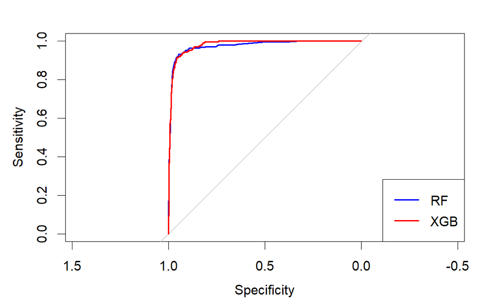

```r
legend(
  "bottomright",
  legend = c("RF", "XGB"),
  col = c("blue", "red"),
  lwd = 2
)
```